# Your Digest for Saturday, Jul 22, 2023 11:59 PM

Sensory symptoms are common but it's *not sensory loss*. *IVIG and plasmapheresis are equally effective.*

> [!TIP] Support patients until they recover  
> Guillain barre can cause significant weakness and can be fatal if not treated properly. With proper management, patients can make a complete recovery.

Nerves show *lymphocytic* infiltrate

**Pathophysiolgy**

> The **pathophysiology** of GBS involves an inflammatory response against either the myelin or the axon of peripheral nerves
1. Acute inflammatory *demyelinating* polyneuropathy (**AIDP**) - commonest**, motor predominant with sensory involvement
   1. AMAN - Acute motor axonal neuropathy - asia, young people.
2. **Weakness** - progressive, symmetrical with absent tendon reflexes.
3. **Back pain** - nerve root inflammation.
4. **Paraesthesia** - patient complains of abnormal sensation but **no/only mild objective** sensory loss..
5. **Dysautonomia** - ileus / tachycardia / bradycardia/ hypotension/ urinary retention.  
   ICU admission indications:
- rapidly progressing weakness
- Impending respiratory failure
- Autonomic instability  
  Immunomodulatory therapy:  
  The time to onset of recovery may be *shortened by approximately 40 to 50 percent* by treatment with plasma exchange (PLEX) or IVIG.  
  Non-ambulatory patients presenting within 4 weeks of symptom onset should be given PLEX or IVIG.  
  Glucocorticoids are *NOT* indicated because evidence shows that there is no benefit. May cause a *delay* in recovery.  
  Monitor for respiratory failure.  
  Use MRC muscle power assessment tool.  
  Intubate and ventilate if impending respiratory failure.  
  **IVIG or plasma exchange** when indicated

## Outcomes of GBS

Approximately 80 percent of patients are able to walk independently and more than half recover completely by one year;  
[Prognostication tool](https://gbstools.erasmusmc.nl/prognosis-tool)

# Bubonic plaque

Yersinia pestis.  
Transmitted by bite of rodent associated flea.  
Fever, headache, chills, and weakness and one or more swollen, painful lymph nodes (called buboes).  
Can be fatal without antibiotics.

Mild *nondisabling symptoms* - no thrombolysis.

# Stroke

[output not shown]

> Globally, **ischemia accounts for 62 percent**, intracerebral hemorrhage 28 percent, and subarachnoid hemorrhage 10 percent of all incident strokes

## Ischemic stroke (60-80%)

### Mechanisms:

Reduction of local or systemic blood supply.  
*Systemic blood supply is reduced* in hypotensive states leading to watershed infarcts.

Local ischemia:

- Thrombosis - plaque ruptures -> thrombosis -> artery to artery embolization
- large artery stenosis:
  - Large vessels include both the extracranial (common and internal carotids, vertebral)
  - and intracranial arterial system (Circle of Willis and proximal branches)
  - *large vessel disease causes local ischemia by **luminal narrowing** which causes*
    - distal blood flow
    - emboli which shoot off distally and obstruct smaller arteries (artery to artery embolization)
    - **Commonest cause --- BY FAR ---for luminal narrowing** in intracranial AND extracranial large vessels is **atherosclerosis**.
    - Other pathologies causing vessel narrowing:
      - Vasculitis - but it is a very rare cause.
- Small artery disease
  - These are pathologies of the intracranial vessels.
  - Main cause of narrowing in this size of vessels if hypertension induced lypohyalinosis. (also atheroma formation at branches from the larger arteies)
  - Smaller calliber vessels supply the deeper brain structures by penetrating into the brain tissue -> Therefore, small artery disease causes **LACUNAR INFARCTS**.

| Extracranial | Intracranial |
| --- | --- |
| Dissection | Dissection |
| Takayasu arteritis | arteritis |
| Giant cell arteritis | Moyamoya syndrome |
|  | Vasonconstriction |

see [[Miscellaneous respiratory medicine#Small vessels vasculitides|vasculitides]]

## haemorrhagic stroke

[output not shown]

#2022BSQ BSQ Q49

> [!INFO] Mnemonic  
> Type III - 3rd letter in alphabet - C for immune **complexes**.

| Type 1 | Type 2 | Type 3 | Type 4 |
| --- | --- | --- | --- |
| commonest type | Goodpasture syndrome, autoimmune anaemias, erythroblastosis faetalis | [[2023-SEMPaper#Systemic Lupus Erythematosus SLE\|SLE]], serum sickness, reactive arthritis, PSGN, Rheumamtoid arthritis | **second most common** |
| Immediate hypersensitivity - eg analphylaxis | 2-24 hours | days to weeks | 2 days |
| IgE (from plasma cells) mediated | **IgG and IgM** - bind to own cell surface molecules -> *complement activated* | **IgG and IgM** antigen antibody *complexes* | **Cell** mediated - *non antibody dependant* - **T cells, monocytes and macrophages** |
| degranulation of mast cells and basophils | complement mediated red cell agglutination and other cell lysis |  | Cytokines which cause cell death and inflammation are released |

# Infectious diarrhoea

#2022BSQ Q54

## Diarrhoea in resource rich settings

> [!TIP] Water diarrhoea  
> **Same day:**
> 1. Norovirus
> 2. clostridium perfringens
> 3. possibly listeria (pregnancy, immunosuppression, extremes of age)

> **Next day:**
> 1. E coli - enteroroxigenic
> 2. most other viruses - (1-3 days) diarrhoea in children, immunocompromised adults

> **Same week**
> 1. Cyclospora

> **Weeks later**
> 1. Giardia 1 to 2 weeks later - day care, swimming pools, travel / camping.
> 2. Cryptosporidium 2-28 days (upto 1 month after) - Associated with day care centers, swimming pools.

> [!TIP] Mnemonics: inflammatory diarrhoea  
> Fever, mucoid or bloody stools show infective diarrhoea:  
> "*Can't Assume Everyone's Your Very Special Sidekick*"

[figure not shown]

> Let's break it down:
> 1. "Can't" - Campylobacter
> 2. "Assume" - Amoebiasis
> 3. "Everyone's" - E. coli
> 4. "Your" - Yersinia
> 5. "Very" - Vibrio parahaemolyticus
> 6. "Special" - Salmonella
> 7. "Sidekick" - Shigella

> **Most of these have P-incu of 1-3 days.** But, *entamoeba - much longer- 1 to 3 weeks*, *yersinia* - slightly longer- 4-6 days, **E-coli 1-8 days.**

## Diarrhoea in resource poor settings

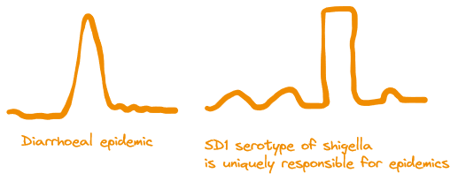

### Epidemic diarrhoea

Main two pathogens of epidemic diarrhoea

1. Cholera (secretory rice water diarrhoea) [[Misc infectious diseases#Cholera]]
2. Shigella dysenteriae - SD1 serotype. (inflammatory diarrhoea - blood + mucous)

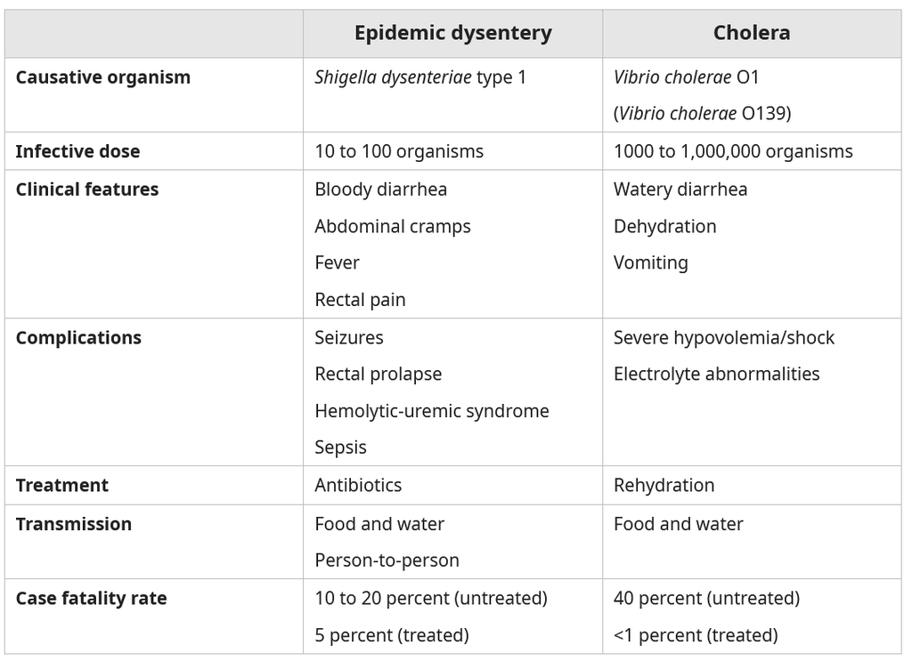

### Non epidemic diarrhoea

Commonest causes of non epidemic watery diarrhoea - E. coli.

> [!TIP] mnemonic
> Acute bloody diarrhoea
> $$
> \Large{C^1S^2E^3}
> $$

Commonest cause of non epidemic bloody diarrhoea - *shigella flexneri* (not dysenteriae)

- other causes of acute bloody diarrhoea
  - Campylobacter
  - Enteroinvasive E coli
  - Enterhemorrhagic E coli
  - Entamoeba histolytica
  - [[Misc infectious diseases#Schistosoma|Schistosoma mansoni]]

# Enterobiasis

Pin worm.  
Humans are considered the only host for *E. vermicularis*  
Infection is commonest in children and institutionalised people.  
Treatment is easy; reinfection is also easy.  
Commonest symptom: itching in the perianal area, possible with excoriation and seconday bacterial infection.  
Perianal itching / scratching contributes to faeco-oral transmission of the parasite.  
Infection of the female genital tract can occur. Can cause abdominal pain mimicking appendicitis.  
Treatment: Albendazole, mebendazole

[figure not shown]

# Strongyloidosis

*Strongyloides stercoralis* : thread worm  
First discovered in french troops returning from vietnam in the 19th century who developed *chronic diarrhoea*.  
Infective stage : **Filariform larva:** -> *penetrates intact skin*.

> [!INFO] How to understand the life cycle;  
> parasite has a free living cycle and parasitic cycle  
> **Eggs can be deposited a) In the host intestine and b) in the environment.**  
> Eggs always produce rhabditiform larvae.  
> Eggs -> rhabditiform larvae -> filariform larvae. (Infective stage) (autoinfection or otherwise).  
> If excreted with stool, rahbditiform larvae can go on to develop into adult *sexual stages* which produce more eggs in the free living cycle.

> Female Adult worm (who live embedded in the submucosa of the small intestine) lays eggs.

> It has been thought that the L3 larvae migrate via the bloodstream and lymphatics to the lungs, where they are eventually coughed up and swallowed. However, L3 larvae appear capable of migrating to the intestine via alternate routes (e.g. through abdominal viscera or connective tissue)

## Symptoms:

Respiratory : Dry cough - *about 1 week after infection*  
Abdominal pain, bloating, intermittent constipation and diarrhoea - *about 3 weeks or later after infeciton* (due to infection of the small intestine)  
Skin: Itchy rash at site of entry; recurrent red rash along thighs and buttocks. - **Larva currens (pathognomonic of Strongyloidiasis)**.  
Disseminated life threatening infection can occur in immunosuppressed people.  
Eosinophilia(+)

### Management:

Ivermectin has been shown to be superior to albendazole.

> **Ivermectin**: binds selectively and with high affinity to *glutamate-gated chloride ion channels* in *invertebrate muscle and nerve cells of microfilaria*.

> **Albendazole** and other similar drugs inhibit the beta tubulin of worms (intracellular cytoplasmic structural protein) -> immobilization and death.

# Skull base fracture

#2022BSQ Q51  
Skull base fracture and associated injuries; [Source](https://www.lhsc.on.ca/critical-care-trauma-centre/basal-skull-fractures)  
[NCBI article](https://www.ncbi.nlm.nih.gov/books/NBK470175/) <- good link  
Cranial nerve injuries: Page 1079 of Moore's clinical anatomy.

P-glycoproteins in the gut can cause efflux of drugs, reducing absorption. Another example of first pass effect.

Phase II reactions result in the formation of readily excreted, *less active*,**nontoxic** substances.

[output not shown]

## DLCO Test:

> **High DLCO is seen in conditions like obesity, asthma**, which are characterized by large lung volumes.